## MAT 321 - PS4

- You can (and probably should) discuss assignments with each others, and the course staff, but you must write and understand any solutions/code that you submit. You can consult any resource you want for this homework, but you should cite sources you used.
- You must upload the assignment to Gradescope before the deadline. You should submit this notebook in .ipynb format, and optinally a single PDF file with your written answers.

# Q1 Diagonalization of Circulant Matrices

In these problem sets, we have used repeatedly that circulant matrices are diagonalized by the DFT to:

- derive fast mat-vecs with circulant and Toeplitz matrices
- derive fast solvers for circulant and perturbed circulant systems
- deblur large datasets of images

That is, we used the fact that:

$$C = F^{-1} \Lambda F $$

where $F$ is the DFT matrix, and $\text{diag}(\Lambda) = Fc$. The goal of this exercise is to prove this identity.

Note that this is an eigendecomposition of $C$, where $V = F^{-1}$ is the matrix of eigenvectors. Recall that the DFT matrix is

$$ F = \frac{1}{\sqrt{n}} \begin{bmatrix} 1 & 1 & 1 & 1 & \cdots & 1 \\ 1 & \omega & \omega^2 & \omega^3 & \cdots & \omega^{n-1} \\ 1 & \omega^2 & \omega^4 & \omega^6 & \cdots & \omega^{2(n-1)} \\ 1 & \omega^3 & \omega^6 & \omega^9 & \cdots & \omega^{2(n-1)} \\ \vdots & \vdots & \vdots & \vdots & \ddots & \ddots \\ 1 & \omega^{n-1} & \omega^{2(n-1)} & \omega^{3(n-1)} & \cdots & \omega^{(n-1)(n-1)} \\ \end{bmatrix} $$

where $\omega = \exp(- \imath 2 \pi / n) $, $\imath^2 = -1$ (note that $\omega$ depends on $n$). Also recall that $F$ with this normalization is unitary, that is $F^{-1} = F^* = \bar{F}^T$, and $F$ is symmetric (but *not hermitian*), so $F^{-1} = \bar{F}$.

We prove this identity in 3 steps:

1. Let $D_n \in \mathbb{R}^{n \times n}$ be the circulant downward shift matrix. For $n = 5$, this matrix is:

$$ D_5 = \begin{bmatrix} & & & & 1 \\ 1 & & & & \\ & 1& & & \\ & & 1& & \\ & & & 1& \\ \end{bmatrix} $$. We will first show that the DFT diagonalizes $D_n$: $D_n = F^{-1} \Gamma F $ for some diagonal matrix $\Gamma$. Here's how to proceed:

- Show that $D_n {F}_{i+1} = \gamma_{i+1} {F}_{i+1} $ where ${F}_{i+1}$ is the $i+1$ column of ${F}$:

$$ F_{i+1} = \frac{1}{\sqrt{n}} \begin{bmatrix} 1 \\ {\omega}^{i}\\ {\omega}^{2i}\\ {\omega}^{3i}\\ \vdots \\ {\omega}^{(n-1)i}\\ \end{bmatrix} $$

and $\gamma_{i+1} = \bar{\omega}^i$.

- Argue that this implies $D_n F = F \bar{\Gamma} $, where $\bar{\Gamma}$ is a diagonal matrix with diagonal entries $\gamma_i$.
- Take the complex conjugate of previous part, and conclude that $D_n = F^{-1} \Gamma F$
2. Write any circulant matrix as an $(n-1)$ degree polynomial in $D_n$. That is, find the coefficients $\alpha_k$ so that:

$$C = \sum_{k=0}^{n-1} \alpha_k D_n^k $$

Recall that $D_n^0$ is defined as the identity. You can do this by inspection.

3. Use the previous two parts to show $C = F^{-1} \Lambda F $ for some diagonal matrix $\Lambda$. Some inspection reveals that $\text{diag}(\Lambda) = Fc$, but you do not need to prove this.

# Q2 The Bartels-Stewart algorithm

In this problem, we derive an algorithm for solving a special kind of matrix equation: Sylvester equations. A Sylvester equation is of the form: $$ AX - XB = F $$ where $A,X,B,F \in \mathbb{R}^{n \times n}$. Using the Kronecker formalism from HW3, we can solve this matrix equation in $\mathcal{O}(n^6)$, but we can do better: the Bartels-Stewart algorithm is an algorithm that solves this equation in $\mathcal{O}(n^3)$. The Bartels-Stewart algorithm is based on one clever observation: if $A$ and $B$ are diagonal matrices, then this equation is easy to solve. Say $A = \text{diag}(d)$, $B = \text{diag}(p)$, then the $(i,j)$-th entry of the Sylvester equation reads: $$ d_i x_{i,j} - x_{i,j} p_j = f_{i,j} $$ i.e., the system is uncoupled and $x_{i,j}$ can be easily found as: $$ x_{i,j} = \frac{f_{i,j}}{d_i - p_j} \ . $$ From this equation, it is clear that there is a unique solution if and only if $d_i - p_j \neq 0 \leftrightarrow d_i \neq p_j$ for all $i,j$.

To solve a general Sylvester equation, Bartels-Stewart reduces a general Sylvester equation to the diagonal case using an eigenvalue decomposition.

## 2.1

Assume $A$ and $B$ are diagonalizable, that their eigenvalues decompositions are $$ A = U \Sigma U^{-1}, \qquad B = V\Lambda V^{-1}, $$ and that $X$ satisfies the Sylvester equation $AX - XB = F$. Show that the matrix $\hat{X} = U^{-1} X V $ satisfies the following transformed (diagonal) Sylvester equation:

$$ \Sigma \hat{X}- \hat{X} \Lambda = \hat{F} $$

for some matrix $\hat{F} $.

## 2.2

Use the previous part to show that if $A$ is symmetric positive definite, and $B$ is symmetric negative definite (i.e. $C := -B$ is symmetric positive definitive), then the Sylvester equation has a unique solution.

## 2.3

Use 1.1 to design and implement an $\mathcal{O}(n^3)$ solver for a general Sylvester equation. You may assume that the matrices are diagonalizable but not SPD.

You may use `np.linalg.eig()` which computes an eigenvalue decomposition of $A$ in $\mathcal{O}(n^3)$.

Reminder: the [number one sin of Numerical Linear Algebra](https://nhigham.com/2022/10/11/seven-sins-of-numerical-linear-algebra/) is to form the inverse of a matrix. In particular, these two commands should be avoided like the plague: `np.linalg.inv(A)` or `np.linalg.solve(A,I)` (they do the same computation). Instead, you should use: `np.linalg.solve(A,F)` to compute $X = A^{-1} F$ and `np.linalg.solve(A.T,F.T).T` to compute $X = F A^{-1} = ({A^{-1}}^T {F}^T)^T$

```python
import numpy as np

def Bartels_Stewart(A,B,F):
    ## ADD YOUR CODE HERE
    X = np.zeros_like(F)
    return X


# THIS CODE IS WRITTEN FOR YOU. NO NEED TO CHANGE IT
n = 10
A = np.random.randn(n,n)
B = np.random.randn(n,n)
X = np.random.randn(n,n)

F = A@X - X@(B)

Xsolve = Bartels_Stewart(A, B, F)

# Should be close to machine epsilon ~1e-14 is fine
print('error: ', np.linalg.norm(Xsolve - X )/np.linalg.norm(X))
```

```
error:  1.0
```

## Q3 Fast PDE Solver: Poisson's Equation

In HW2, we derived a numerical scheme to solve Poisson's equation in 1D:

$$ - \frac{d^2}{dx^2} u(x) = f(x), \quad u(0) = u(1) = 0. $$

The discretized system takes the form:

$$ T u = h^2 f, $$

where

$$ T = \begin{bmatrix} 2 & -1 & & & \\ -1 & 2 & -1 & & \\ & -1 & 2 & -1 & \\ & & \ddots & \ddots & \ddots \\ & & & -1 & 2 \\ \end{bmatrix}, \quad f = \begin{bmatrix} f(h) \\ f(2h) \\ \vdots \\ f(nh) \\ \end{bmatrix}, $$

and $ h = \frac{1}{n+1} $. Since $ T \in \mathbb{R}^{n \times n} $ is tridiagonal, we can solve this system in $ O(n) $ operations using a banded LU. All variations of the 1D problem are similarly straightforward.

The 2D case is more interesting. Consider Poisson's equation on the unit square with homogeneous Dirichlet boundary conditions:

$$ - \frac{d^2}{dx^2} u(x,y) - \frac{d^2}{dy^2} u(x,y) = f(x,y), \\ u(x,0) = u(x,1) = 0, \\ u(0,y) = u(1,y) = 0. $$

Poisson's in 2D and 3D equation models diffusion processes, with applications in fluid flow, heat transfer, and chemical transport. It also serves as a foundational problem for more complex equations.

We discretize the equation on an $ n \times n $ uniform grid $ (x_i, y_j) $, where $ x_i = ih $, $ y_j = jh $, and $ h = \frac{1}{n+1} $. Let $ F_{i,j} = h^2 f(x_i, y_j) $; that is, the entry $ (i,j) $ of matrix $ F \in \mathbb{R}^{n \times n} $ is $ h^2 $ times the value of $ f $ at $ (x_i, y_j) $. We seek approximate values $ U_{i,j} \approx u(x_i, y_j) $ using finite differences.

The operator $ u \rightarrow - \frac{d^2}{dx^2} u $ with boundary conditions $ u(x,0) = u(x,1) = 0 $ can be applied independently to the columns of $ U $, resulting in $ U \rightarrow TU $. Similarly, the operator $ u \rightarrow - \frac{d^2}{dy^2} u $ with boundary conditions $ u(0,y) = u(1,y) = 0 $ can be applied independently to the rows of $ U $, yielding $ U \rightarrow UT^T = UT $.

Therefore, the discretized operator becomes $ U \rightarrow TU + UT $, leading to the matrix equation:

$$ TU + UT = F. $$

Our goal is to solve this linear system for $ U $. Using the Kronecker formalism from the previous homework, we could solve this in $ O(n^6) $ operations—not ideal. The Bartels-Stewart algorithm improves this to $ O(n^3) $ complexity, but we can do even better. A key property of the second-order finite difference matrix $ T $ is that its eigenvalue decomposition can be computed analytically:

$$ T = S^{-1} \Lambda S, $$

where $ S $ is the Discrete Sine Transform (DST) matrix with components $ S_{kj} = \sqrt{\tfrac{2}{n+1}} \sin\left(\tfrac{kj\pi}{n+1}\right) $, and the eigenvalues are $ \lambda_j = 4 \sin^2 \left( \tfrac{j \pi}{2(n+1)} \right) $. The DST is the imaginary part of the Discrete Fourier Transform (DFT). Thanks to this connection, we can compute $ Sx $ in $ \mathcal{O}(n \log n) $ time using the Fast Fourier Transform (FFT), available via `scipy.fft.dst(x, type=1, norm="ortho")`. The DST matrix is orthogonal and symmetric when properly normalized (`norm="ortho"`), so $ S = S^T = S^{-1} $.

Your task is to write a solver for Poisson's equation with $ \mathcal{O}(n^2 \log n) $ complexity using these properties of $ T $.

**Programming Note:** To compute $ SX $ (where $ X $ is a matrix), use `scipy.fft.dst(X, type=1, norm="ortho", axis=1)`. To compute $ XS$, use `scipy.fft.dst(X, type=1, norm="ortho", axis=0)`. You can use the `dst(X, axis=0)` function defined below to keep the syntax nicer. A function which returns the eigenvalues of $T$ is also provided for you below.

```
Bartels-Stewart error (if this doesnt work, fix previous question!) 1.0
Fast poisson solver error 1.0
```

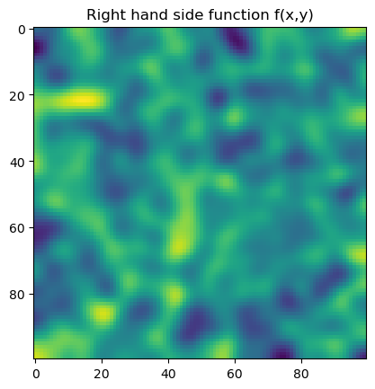

[figure not shown]

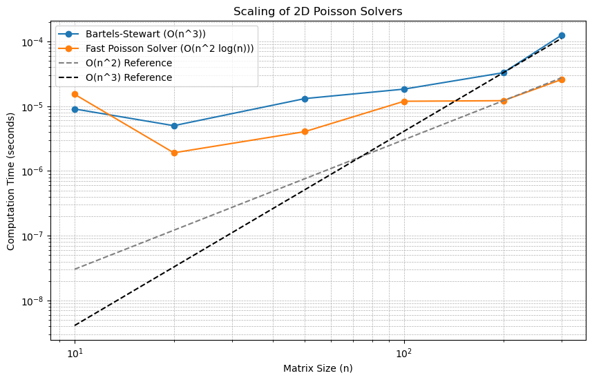

```python
import numpy as np
import matplotlib.pyplot as plt
import scipy.fft

def fast_2d_poisson_solver(F):
    # ADD YOUR CODE HERE
    X = np.zeros_like(F)
    return X

## ALL THE CODE BELOW IS PROVIDED FOR YOU.

# A helper function you can use if you want
def dst(X,axis =0):
    return scipy.fft.dst(X, type = 1, norm = "ortho", axis =axis)

# Computes eigenvalues of the Tridiagonal matrix from known analytical formula
def get_eigenvalues_of_T(n):
    return 4 * (np.sin(np.arange(1,n+1) * np.pi / (2*( n + 1)))**2)

# Get the matrix explicitely, useful for debugging
def get_second_order_diff_matrix(n):
    T = np.diag(2 * np.ones(n)) + np.diag(-1 *  np.ones(n-1), k = 1) + np.diag(-1 * np.ones(n-1) , k = -1)
    return T

### TEST FOR CORRECTNESS

n = 100
h = 1 / (n+1)
from scipy.ndimage import gaussian_filter
F = gaussian_filter(np.random.randn(n,n) * h**2 , 3) # An interesting looking RHS function f

# O(n^3) way using your Bartles-Stewart code:
T = get_second_order_diff_matrix(n)
X = Bartels_Stewart(T, -T, F)
print('Bartels-Stewart error (if this doesnt work, fix previous question!)',np.linalg.norm(T @X + X@T - F) / np.linalg.norm(F))

# O(n^2 log(n)) way using your fast Poisson code:
X2 = fast_2d_poisson_solver(F)
print('Fast poisson solver error', np.linalg.norm(T @X2 + X2@T - F) / np.linalg.norm(F))


plt.figure()
plt.imshow(F)
plt.title("Right hand side function f(x,y)")
plt.show()


plt.figure()
plt.imshow(X2)
plt.title("Approximate solution u(x,y)")
plt.show()


### TEST FOR COMPLEXITY

### A scaling plot

import time
# Define the scaling experiment
# This one takes 1s on my laptop
sizes = [10, 20, 50, 100, 200, 300]  # Increase n gradually

# If you think your method is right, uncomment this! It takes ~10s on my laptop
# sizes = [10, 20, 50, 100, 200, 300, 500, 1000]  # Increase n gradually

bartels_times = []
fast_times = []

for n in sizes:
    h = 1 / (n + 1)
    F = np.ones((n, n)) * h**2

    # Time Bartels-Stewart solver
    T = get_second_order_diff_matrix(n)
    start = time.time()
    X_bartels = Bartels_Stewart(T, -T, F)
    bartels_times.append(time.time() - start)

    # Time the fast Poisson solver
    start = time.time()
    X_fast = fast_2d_poisson_solver(F)
    fast_times.append(time.time() - start)

# Create reference lines for O(n^2) and O(n^3) scaling
sizes_np = np.array(sizes)
o_n2_ref = (sizes_np ** 2) * (fast_times[4] / sizes_np[4] ** 2)  # Normalized to first data point
o_n3_ref = (sizes_np ** 3) * (bartels_times[4] / sizes_np[4] ** 3)  # Normalized to first data point

# Plot the scaling results with reference lines
plt.figure(figsize=(10, 6))
plt.plot(sizes, bartels_times, label="Bartels-Stewart (O(n^3))", marker="o")
plt.plot(sizes, fast_times, label="Fast Poisson Solver (O(n^2 log(n)))", marker="o")
plt.plot(sizes, o_n2_ref, '--', label="O(n^2) Reference", color='gray')
plt.plot(sizes, o_n3_ref, '--', label="O(n^3) Reference", color='black')

# Add plot labels and formatting
plt.xlabel("Matrix Size (n)")
plt.ylabel("Computation Time (seconds)")
plt.title("Scaling of 2D Poisson Solvers")
plt.legend()
plt.xscale("log")  # Set x-axis to logarithmic scale
plt.yscale("log")  # Set y-axis to logarithmic scale
plt.grid(True, which="both", linestyle="--", linewidth=0.5)
plt.show()
```

## Q4. Crafting the jewel

We spent two weeks deriving one of the jewels of numerical linear algebra: the shifted-QR algorithm. Time to pull all the pieces together. When applied to real symmetric matrices, the algorithm looks as follows.

> $Q_0 A^{(0)} Q_0 ^T = A \qquad $ (1) (Compute a reduction to tridiagonal by Householder Reflection)

> $M \leftarrow m$

> for $k = 1,2, \dots$

> > $\mu_k = A_{M,M}^{(k-1)} \qquad $ (Compute Rayleigh quotient)

> > $Q^{(k)}, R^{(k)} \leftarrow A^{(k-1)} - \mu_k I \qquad $ (2) (Compute QR decomposition of the shifted matrix)

> > $A^{(k)} \leftarrow R^{(k)} Q^{(k)} + \mu_k I \qquad $ (3) (Recombine factors)

> > if $|A_{M,M-1}^{(k)} | < \text{tol}$: $\qquad $ (4) (If converged to eigenvalue)

> > > Add $A_{M,M}^{(k)}$ to list of eigenvalues

> > > $A^{(k)} \leftarrow A^{(k)}_{[1:M-1, 1:M-1]} \qquad $ (Deflate: ignore last row and column)

> > > $M \leftarrow M-1$

> > if $ M = 1: $ (The trivial 1x1 matrix case: the entry is the eigenvalue)

> > > Add $A_{1,1}^{(k)}$ to list of eigenvalues

> > > terminate

> end while
- Step (1) was implemented in precept 8 in $O(m^3)$
- Step (2) was implemented in HW3 $O(m^2)$ for (nonsymmetric). Use your implementation from HW2 (or better yet, modify it to make it $O(m)$ for tridiagonal (optional)!).
- Step (3) Step 3 is a matrix-matrix multiply which is $O(m^3)$ naively. However, it could be implemented in $O(m)$ since it is a matrix-matrix multiply between two very structured and sparse matrices (optional).
- Step (4) is the deflation step. We check if we have converged to an eigenvalue.

As a result of the shifting we recover the $O(\epsilon^3)$ converge of the Rayleigh quotient iteration. Thus, we expect to need only a handful of iterations per eigenvalues (3-4).

Your task is to implement the shifted-QR algorithm above and keep track of how many QR iterations you are doing. Make sure that you only need $< 4 n$ QR iterations to compute all eigenvalues.

```python
def shifted_QR_iteration(A, tol =1e-13):
    eigenvalues = []
    n_iters = 0
    ## ADD YOUR CODE HERE


    while ():
        ## You can replace this loop, with whatever you want, but make sure you keep track of the number of iterations
        # (specifically, the number of QR decomposition you are computing)
        n_iters +=1

    eigenvalues = np.zeros(A.shape[0])
    return eigenvalues,  n_iters

n = 100
# A test case: a random symmetric matrix
A = np.random.randn(n,n)
A = A + A.T

# Compute eigenvalues with built-in:
eigvals1 = np.linalg.eigvals(A)

# Compute with your code
eigvals2, n_iters = shifted_QR_iteration(A.copy())

# Check that the number eigenvalues are correct:
print('eigenvalue error:', np.max(np.sort(eigvals1) - np.sort(eigvals2)))

# Number of n_iters divided by n:
# Should be < 4
print('number of QR iterations per eigenvalues:', n_iters/n)
```

```
eigenvalue error: 27.125159747208166
number of QR iterations per eigenvalues: 0.0
```

# Q5. Spectral Embedding

In this problem we explore nonlinear dimensionality reduction for high-dimensional data. Our goal is to represent a complex dataset using only one parameter. As a motivating example, consider a disordered sequence of images showing a rotating duck: each image lives in a high-dimensional pixel space, yet the underlying variation can be described by a single parameter (the rotation angle).

```
Loaded 47 images from './spinning_duck' with size 128x128
```

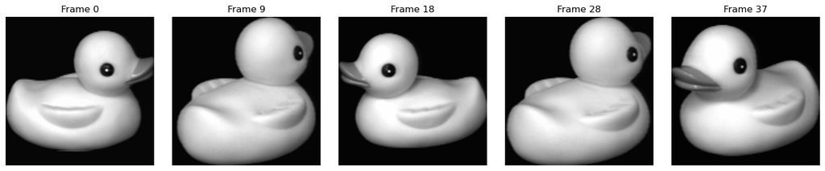

```python
from PIL import Image
import glob
import matplotlib.pyplot as plt
import numpy as np
import os

# Load images from the spinning_duck directory in their existing order
files = sorted(glob.glob("./spinning_duck/*.png"))

# Load the images as grayscale and stack them
frames = np.stack([np.array(Image.open(f).convert("L"), dtype=np.float64) for f in files])
N, H, W = frames.shape
print(f"Loaded {N} images from './spinning_duck' with size {H}x{W}")

# Visualize a few frames to check
fig, axes = plt.subplots(1, 5, figsize=(15, 3))
for ax, idx in zip(axes, [0, N//5, 2*N//5, 3*N//5, 4*N//5, N-1]):
    ax.imshow(frames[idx], cmap='gray')
    ax.set_title(f'Frame {idx}')
    ax.axis('off')
plt.tight_layout()
plt.show()
```

We will construct a one-dimensional embedding for such data using the eigenvectors of a similarity matrix.

Let $W$ be the similarity matrix, with entries

$$ w_{ij} = \exp\left(-\frac{\|y_i - y_j\|_2^2}{2\sigma^2}\right), \qquad y_i \in \mathbb{R}^{128^2}. $$ where $\{y_i\}_{i=1}^{N}$ are images and $\sigma$ is a fixed bandwidth parameter.

The only assumptions we need to apply this dimensional reduction method is that the similarity matrix $W$ is symmetric with nonnegative entries; it need not come from a Gaussian kernel specifically.

We wish to assign each image $y_i$ a scalar value $x_i \in \mathbb{R}$ such that similar images are mapped close together. To quantify this, define the embedding vector $x = (x_1, \dots, x_N)$ and energy

$$ E(x) = \sum_{i,j=1}^N w_{ij} (x_i - x_j)^2. $$

Large weights $w_{ij}$ strongly penalize separating $x_i$ and $x_j$. Our task is to find $x$ that minimizes $E(x)$.

### Part A

Let $d = W\mathbf{1}$, where $\mathbf{1}$ is the all-ones vector, and define $D = \mathrm{diag}(d)$.

Find a matrix $L$ in terms of $W$ and $D$ such that

$$ E(x) = 2\, x^\top L x. $$

Prove that $L$ is symmetric and positive semidefinite.

### Part B

The minimizer $x = \alpha \mathbf{1}$ (for any $\alpha$) is useless — it maps all data points to the same location. Additionally, scaling $x$ shrinks $E(x)$ arbitrarily. To avoid this, we constrain the solution:

$$ \min_{x \in \mathbb{R}^N} x^\top L x \qquad \text{s.t.} \qquad \|x\|_2 = 1, \quad \mathbf{1}^\top x = 0. $$

Introducing Lagrange multipliers gives the Lagrangian

$$ \mathcal{L}(x,\lambda,\mu) = x^\top L x - \lambda (\|x\|_2^2 - 1) - \mu (\mathbf{1}^\top x). $$

Derive the first-order optimality conditions and show that any critical point satisfies

$$ Lx = \lambda x, \qquad \mathbf{1}^\top x = 0. $$

### Part C

Express the constrained minimizer in terms of the eigenvectors of $L$, assuming $L$ has a single zero eigenvalue (i.e., the nullspace of $L$ is spanned by $\mathbf{1}$).